# Sandeep Immadi SMDM Project 9th May Jupyter file

```python
import numpy as np
import pandas as pd
from matplotlib import pyplot as plt
%matplotlib inline
import seaborn as sns
import statsmodels.api as sm
import scipy.stats as stats
import copy
import os
from warnings import filterwarnings
filterwarnings("ignore")
import math
from scipy.stats import   ttest_1samp, ttest_ind
import statsmodels.stats.api as sm
```

```python
wsd=pd.read_csv('Wholesale+Customers+Data.csv')
wsd
```

|  | Buyer/Spender | Channel | Region | Fresh | Milk | Grocery | Frozen | Detergents_Paper | Delicatessen |
| --- | --- | --- | --- | --- | --- | --- | --- | --- | --- |
| 0 | 1 | Retail | Other | 12669 | 9656 | 7561 | 214 | 2674 | 1338 |
| 1 | 2 | Retail | Other | 7057 | 9810 | 9568 | 1762 | 3293 | 1776 |
| 2 | 3 | Retail | Other | 6353 | 8808 | 7684 | 2405 | 3516 | 7844 |
| 3 | 4 | Hotel | Other | 13265 | 1196 | 4221 | 6404 | 507 | 1788 |
| 4 | 5 | Retail | Other | 22615 | 5410 | 7198 | 3915 | 1777 | 5185 |
| ... | ... | ... | ... | ... | ... | ... | ... | ... | ... |
| 435 | 436 | Hotel | Other | 29703 | 12051 | 16027 | 13135 | 182 | 2204 |
| 436 | 437 | Hotel | Other | 39228 | 1431 | 764 | 4510 | 93 | 2346 |
| 437 | 438 | Retail | Other | 14531 | 15488 | 30243 | 437 | 14841 | 1867 |
| 438 | 439 | Hotel | Other | 10290 | 1981 | 2232 | 1038 | 168 | 2125 |
| 439 | 440 | Hotel | Other | 2787 | 1698 | 2510 | 65 | 477 | 52 |

440 rows × 9 columns

```python
wsd.info()
```

```
<class 'pandas.core.frame.DataFrame'>
RangeIndex: 440 entries, 0 to 439
Data columns (total 9 columns):
 #   Column            Non-Null Count  Dtype
---  ------            --------------  -----
 0   Buyer/Spender     440 non-null    int64
 1   Channel           440 non-null    object
 2   Region            440 non-null    object
 3   Fresh             440 non-null    int64
 4   Milk              440 non-null    int64
 5   Grocery           440 non-null    int64
 6   Frozen            440 non-null    int64
 7   Detergents_Paper  440 non-null    int64
 8   Delicatessen      440 non-null    int64
dtypes: int64(7), object(2)
memory usage: 31.1+ KB
```

# Use methods of descriptive statistics to summarize data. Which Region and which Channel spent the most? Which Region and which Channel spent the least?

```python
# summary of data
wsd.describe()
```

|  | Buyer/Spender | Fresh | Milk | Grocery | Frozen | Detergents_Paper | Delicatessen |
| --- | --- | --- | --- | --- | --- | --- | --- |
| count | 440.000000 | 440.000000 | 440.000000 | 440.000000 | 440.000000 | 440.000000 | 440.000000 |
| mean | 220.500000 | 12000.297727 | 5796.265909 | 7951.277273 | 3071.931818 | 2881.493182 | 1524.870455 |
| std | 127.161315 | 12647.328865 | 7380.377175 | 9503.162829 | 4854.673333 | 4767.854448 | 2820.105937 |
| min | 1.000000 | 3.000000 | 55.000000 | 3.000000 | 25.000000 | 3.000000 | 3.000000 |
| 25% | 110.750000 | 3127.750000 | 1533.000000 | 2153.000000 | 742.250000 | 256.750000 | 408.250000 |
| 50% | 220.500000 | 8504.000000 | 3627.000000 | 4755.500000 | 1526.000000 | 816.500000 | 965.500000 |
| 75% | 330.250000 | 16933.750000 | 7190.250000 | 10655.750000 | 3554.250000 | 3922.000000 | 1820.250000 |
| max | 440.000000 | 112151.000000 | 73498.000000 | 92780.000000 | 60869.000000 | 40827.000000 | 47943.000000 |

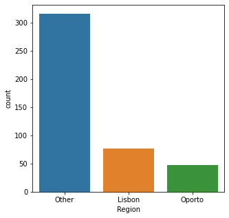

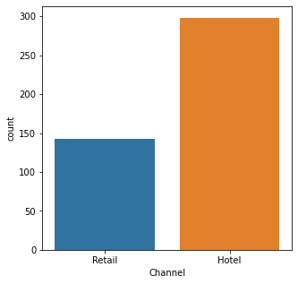

```python
# Which Region and which Channel spent the most?
plt.figure(figsize=(5,5))
sns.countplot(wsd["Region"])
plt.show()
plt.figure(figsize=(5,5))
sns.countplot(wsd["Channel"])
plt.show()
```

```python
# Adding new column to get the total
wsd['Total'] = wsd['Fresh'] + wsd['Milk']+ wsd['Grocery']+ wsd['Frozen']+ wsd['Detergents_Paper']+ wsd['Delicatessen']
wsd
```

|  | Buyer/Spender | Channel | Region | Fresh | Milk | Grocery | Frozen | Detergents_Paper | Delicatessen | Total |
| --- | --- | --- | --- | --- | --- | --- | --- | --- | --- | --- |
| 0 | 1 | Retail | Other | 12669 | 9656 | 7561 | 214 | 2674 | 1338 | 34112 |
| 1 | 2 | Retail | Other | 7057 | 9810 | 9568 | 1762 | 3293 | 1776 | 33266 |
| 2 | 3 | Retail | Other | 6353 | 8808 | 7684 | 2405 | 3516 | 7844 | 36610 |
| 3 | 4 | Hotel | Other | 13265 | 1196 | 4221 | 6404 | 507 | 1788 | 27381 |
| 4 | 5 | Retail | Other | 22615 | 5410 | 7198 | 3915 | 1777 | 5185 | 46100 |
| ... | ... | ... | ... | ... | ... | ... | ... | ... | ... | ... |
| 435 | 436 | Hotel | Other | 29703 | 12051 | 16027 | 13135 | 182 | 2204 | 73302 |
| 436 | 437 | Hotel | Other | 39228 | 1431 | 764 | 4510 | 93 | 2346 | 48372 |
| 437 | 438 | Retail | Other | 14531 | 15488 | 30243 | 437 | 14841 | 1867 | 77407 |
| 438 | 439 | Hotel | Other | 10290 | 1981 | 2232 | 1038 | 168 | 2125 | 17834 |
| 439 | 440 | Hotel | Other | 2787 | 1698 | 2510 | 65 | 477 | 52 | 7589 |

440 rows × 10 columns

```python
wsd.groupby("Region").sum()
```

| Region | Buyer/Spender | Fresh | Milk | Grocery | Frozen | Detergents_Paper | Delicatessen | Total |
| --- | --- | --- | --- | --- | --- | --- | --- | --- |
| Lisbon | 18095 | 854833 | 422454 | 570037 | 231026 | 204136 | 104327 | 2386813 |
| Oporto | 14899 | 464721 | 239144 | 433274 | 190132 | 173311 | 54506 | 1555088 |
| Other | 64026 | 3960577 | 1888759 | 2495251 | 930492 | 890410 | 512110 | 10677599 |

```python
wsd.groupby("Channel").sum()
```

| Channel | Buyer/Spender | Fresh | Milk | Grocery | Frozen | Detergents_Paper | Delicatessen | Total |
| --- | --- | --- | --- | --- | --- | --- | --- | --- |
| Hotel | 71034 | 4015717 | 1028614 | 1180717 | 1116979 | 235587 | 421955 | 7999569 |
| Retail | 25986 | 1264414 | 1521743 | 2317845 | 234671 | 1032270 | 248988 | 6619931 |

Inference:  
- Region and Channel spent the most: Other (10677599) and Hotel (7999569)  
- Region and Channel spent the least: Oporto (1555088) and Retail (6619931)

# There are 6 different varieties of items that are considered. Describe and comment/explain all the varieties across Region and Channel? Provide a detailed justification for your answer.

```python
wsd.groupby("Region").mean()
```

| Region | Buyer/Spender | Fresh | Milk | Grocery | Frozen | Detergents_Paper | Delicatessen | Total |
| --- | --- | --- | --- | --- | --- | --- | --- | --- |
| Lisbon | 235.000000 | 11101.727273 | 5486.415584 | 7403.077922 | 3000.337662 | 2651.116883 | 1354.896104 | 30997.571429 |
| Oporto | 317.000000 | 9887.680851 | 5088.170213 | 9218.595745 | 4045.361702 | 3687.468085 | 1159.702128 | 33086.978723 |
| Other | 202.613924 | 12533.471519 | 5977.085443 | 7896.363924 | 2944.594937 | 2817.753165 | 1620.601266 | 33789.870253 |

```python
wsd.groupby("Region").std()
```

| Region | Buyer/Spender | Fresh | Milk | Grocery | Frozen | Detergents_Paper | Delicatessen | Total |
| --- | --- | --- | --- | --- | --- | --- | --- | --- |
| Lisbon | 22.371857 | 11557.438575 | 5704.856079 | 8496.287728 | 3092.143894 | 4208.462708 | 1345.423340 | 20321.813773 |
| Oporto | 13.711309 | 8387.899211 | 5826.343145 | 10842.745314 | 9151.784954 | 6514.717668 | 1050.739841 | 24234.507325 |
| Other | 143.615303 | 13389.213115 | 7935.463443 | 9537.287778 | 4260.126243 | 4593.051613 | 3232.581660 | 27949.337752 |

```python
# Coefficient of variation
wsd.groupby(["Region"])['Fresh', 'Milk','Grocery','Frozen','Detergents_Paper','Delicatessen'].std()/wsd.groupby(["Region"])['Fresh', 'Milk','Grocery','Frozen','Detergents_Paper','Delicatessen'].mean()
```

| Region | Fresh | Milk | Grocery | Frozen | Detergents_Paper | Delicatessen |
| --- | --- | --- | --- | --- | --- | --- |
| Lisbon | 1.041049 | 1.039815 | 1.147670 | 1.030599 | 1.587430 | 0.993008 |
| Oporto | 0.848318 | 1.145076 | 1.176182 | 2.262291 | 1.766718 | 0.906043 |
| Other | 1.068277 | 1.327648 | 1.207808 | 1.446761 | 1.630040 | 1.994680 |

```python
wsd.groupby("Channel").mean()
```

| Channel | Buyer/Spender | Fresh | Milk | Grocery | Frozen | Detergents_Paper | Delicatessen | Total |
| --- | --- | --- | --- | --- | --- | --- | --- | --- |
| Hotel | 238.369128 | 13475.560403 | 3451.724832 | 3962.137584 | 3748.251678 | 790.560403 | 1415.956376 | 26844.191275 |
| Retail | 183.000000 | 8904.323944 | 10716.500000 | 16322.852113 | 1652.612676 | 7269.507042 | 1753.436620 | 46619.232394 |

```python
wsd.groupby("Channel").std()
```

| Channel | Buyer/Spender | Fresh | Milk | Grocery | Frozen | Detergents_Paper | Delicatessen | Total |
| --- | --- | --- | --- | --- | --- | --- | --- | --- |
| Hotel | 120.910343 | 13831.687502 | 4352.165571 | 3545.513391 | 5643.912500 | 1104.093673 | 3147.426922 | 22164.839073 |
| Retail | 132.136132 | 8987.714750 | 9679.631351 | 12267.318094 | 1812.803662 | 6291.089697 | 1953.797047 | 29346.866491 |

```python
# Coefficient of variation
wsd.groupby(["Channel"])['Fresh', 'Milk','Grocery','Frozen','Detergents_Paper','Delicatessen'].std()/wsd.groupby(["Channel"])['Fresh', 'Milk','Grocery','Frozen','Detergents_Paper','Delicatessen'].mean()
```

| Channel | Fresh | Milk | Grocery | Frozen | Detergents_Paper | Delicatessen |
| --- | --- | --- | --- | --- | --- | --- |
| Hotel | 1.026428 | 1.260867 | 0.894849 | 1.505745 | 1.396596 | 2.222828 |
| Retail | 1.009365 | 0.903246 | 0.751543 | 1.096932 | 0.865408 | 1.114267 |

```python
# Skewness
Skewness = pd.DataFrame({'Skewness' : [stats.skew(wsd.Fresh),stats.skew(wsd.Milk),stats.skew(wsd.Grocery),stats.skew(wsd.Frozen),stats.skew(wsd.Detergents_Paper),stats.skew(wsd.Delicatessen)]},
                        index=['Fresh', 'Milk','Grocery','Frozen','Detergents_Paper','Delicatessen'])
Skewness
```

|  | Skewness |
| --- | --- |
| Fresh | 2.552583 |
| Milk | 4.039922 |
| Grocery | 3.575187 |
| Frozen | 5.887826 |
| Detergents_Paper | 3.619458 |
| Delicatessen | 11.113534 |

Inference:  
From the above observations by considering mean, std, CV, skewness we can see that the behaviour in all items (Channel, Region) are different.

# On the basis of the descriptive measure of variability, which item shows the most inconsistent behaviour? Which items shows the least inconsistent behaviour?

```python
# Finding CV of each item
np.std(wsd['Fresh']) / np.mean(wsd['Fresh'])
```

```
1.0527196084948245
```

```python
np.std(wsd['Milk']) / np.mean(wsd['Milk'])
```

```
1.2718508307424503
```

```python
np.std(wsd['Grocery']) / np.mean(wsd['Grocery'])
```

```
1.193815447749267
```

```python
np.std(wsd['Frozen']) / np.mean(wsd['Frozen'])
```

```
1.5785355298607762
```

```python
np.std(wsd['Detergents_Paper']) / np.mean(wsd['Detergents_Paper'])
```

```
1.6527657881041729
```

```python
np.std(wsd['Delicatessen']) / np.mean(wsd['Delicatessen'])
```

```
1.8473041039189306
```

Inference:  
While comparing among variables whose means showed wide differences. Taken the coefficient of variation as a descriptive measure, because it normalizes the standard deviation with respect to the mean.  
- Fresh items have the lowest coefficient of variation. Hence, it is least inconsistent behaviour.  
- Delicatessen has the highest coefficient of variation. Hence, it is the most inconsistent behaviour.

# Are there any outliers in the data? Back up your answer with a suitable plot/technique with the help of detailed comments.

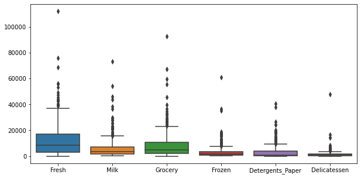

```python
plt.figure(figsize=(10,5))
sns.boxplot(data=wsd[['Fresh', 'Milk','Grocery', 'Frozen', 'Detergents_Paper', 'Delicatessen']]);
```

Inference :  
There are outliers within a data set in all the items. we can see that a data point that is located outside the whiskers of the box plot.

# On the basis of your analysis, what are your recommendations for the business? How can your analysis help the business to solve its problem? Answer from the business perspective.

```python
corr = wsd.corr()
corr
```

|  | Buyer/Spender | Fresh | Milk | Grocery | Frozen | Detergents_Paper | Delicatessen | Total |
| --- | --- | --- | --- | --- | --- | --- | --- | --- |
| Buyer/Spender | 1.000000 | -0.061151 | -0.162290 | -0.140509 | 0.053802 | -0.134365 | -0.101845 | -0.150745 |
| Fresh | -0.061151 | 1.000000 | 0.100510 | -0.011854 | 0.345881 | -0.101953 | 0.244690 | 0.575178 |
| Milk | -0.162290 | 0.100510 | 1.000000 | 0.728335 | 0.123994 | 0.661816 | 0.406368 | 0.776909 |
| Grocery | -0.140509 | -0.011854 | 0.728335 | 1.000000 | -0.040193 | 0.924641 | 0.205497 | 0.740680 |
| Frozen | 0.053802 | 0.345881 | 0.123994 | -0.040193 | 1.000000 | -0.131525 | 0.390947 | 0.388436 |
| Detergents_Paper | -0.134365 | -0.101953 | 0.661816 | 0.924641 | -0.131525 | 1.000000 | 0.069291 | 0.633882 |
| Delicatessen | -0.101845 | 0.244690 | 0.406368 | 0.205497 | 0.390947 | 0.069291 | 1.000000 | 0.496849 |
| Total | -0.150745 | 0.575178 | 0.776909 | 0.740680 | 0.388436 | 0.633882 | 0.496849 | 1.000000 |

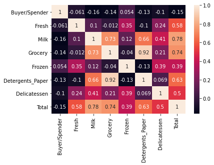

```python
sns.heatmap(corr, annot=True)
```

# Problem 2 :

```python
df = pd.read_csv('Survey-1.csv')
df
```

|  | ID | Gender | Age | Class | Major | Grad Intention | GPA | Employment | Salary | Social Networking | Satisfaction | Spending | Computer | Text Messages |
| --- | --- | --- | --- | --- | --- | --- | --- | --- | --- | --- | --- | --- | --- | --- |
| 0 | 1 | Female | 20 | Junior | Other | Yes | 2.9 | Full-Time | 50.0 | 1 | 3 | 350 | Laptop | 200 |
| 1 | 2 | Male | 23 | Senior | Management | Yes | 3.6 | Part-Time | 25.0 | 1 | 4 | 360 | Laptop | 50 |
| 2 | 3 | Male | 21 | Junior | Other | Yes | 2.5 | Part-Time | 45.0 | 2 | 4 | 600 | Laptop | 200 |
| 3 | 4 | Male | 21 | Junior | CIS | Yes | 2.5 | Full-Time | 40.0 | 4 | 6 | 600 | Laptop | 250 |
| 4 | 5 | Male | 23 | Senior | Other | Undecided | 2.8 | Unemployed | 40.0 | 2 | 4 | 500 | Laptop | 100 |
| ... | ... | ... | ... | ... | ... | ... | ... | ... | ... | ... | ... | ... | ... | ... |
| 57 | 58 | Female | 21 | Senior | International Business | No | 2.4 | Part-Time | 40.0 | 1 | 3 | 1000 | Laptop | 10 |
| 58 | 59 | Female | 20 | Junior | CIS | No | 2.9 | Part-Time | 40.0 | 2 | 4 | 350 | Laptop | 250 |
| 59 | 60 | Female | 20 | Sophomore | CIS | No | 2.5 | Part-Time | 55.0 | 1 | 4 | 500 | Laptop | 500 |
| 60 | 61 | Female | 23 | Senior | Accounting | Yes | 3.5 | Part-Time | 30.0 | 2 | 3 | 490 | Laptop | 50 |
| 61 | 62 | Female | 23 | Senior | Economics/Finance | No | 3.2 | Part-Time | 70.0 | 2 | 3 | 250 | Laptop | 0 |

62 rows × 14 columns

```python
df.describe().T
```

|  | count | mean | std | min | 25% | 50% | 75% | max |
| --- | --- | --- | --- | --- | --- | --- | --- | --- |
| ID | 62.0 | 31.500000 | 18.041619 | 1.0 | 16.25 | 31.50 | 46.75 | 62.0 |
| Age | 62.0 | 21.129032 | 1.431311 | 18.0 | 20.00 | 21.00 | 22.00 | 26.0 |
| GPA | 62.0 | 3.129032 | 0.377388 | 2.3 | 2.90 | 3.15 | 3.40 | 3.9 |
| Salary | 62.0 | 48.548387 | 12.080912 | 25.0 | 40.00 | 50.00 | 55.00 | 80.0 |
| Social Networking | 62.0 | 1.516129 | 0.844305 | 0.0 | 1.00 | 1.00 | 2.00 | 4.0 |
| Satisfaction | 62.0 | 3.741935 | 1.213793 | 1.0 | 3.00 | 4.00 | 4.00 | 6.0 |
| Spending | 62.0 | 482.016129 | 221.953805 | 100.0 | 312.50 | 500.00 | 600.00 | 1400.0 |
| Text Messages | 62.0 | 246.209677 | 214.465950 | 0.0 | 100.00 | 200.00 | 300.00 | 900.0 |

```python
df.info()
```

```
<class 'pandas.core.frame.DataFrame'>
RangeIndex: 62 entries, 0 to 61
Data columns (total 14 columns):
 #   Column             Non-Null Count  Dtype
---  ------             --------------  -----
 0   ID                 62 non-null     int64
 1   Gender             62 non-null     object
 2   Age                62 non-null     int64
 3   Class              62 non-null     object
 4   Major              62 non-null     object
 5   Grad Intention     62 non-null     object
 6   GPA                62 non-null     float64
 7   Employment         62 non-null     object
 8   Salary             62 non-null     float64
 9   Social Networking  62 non-null     int64
 10  Satisfaction       62 non-null     int64
 11  Spending           62 non-null     int64
 12  Computer           62 non-null     object
 13  Text Messages      62 non-null     int64
dtypes: float64(2), int64(6), object(6)
memory usage: 6.9+ KB
```

```python
df.isnull().values.any()
```

```
False
```

# 2.1. For this data, construct the following contingency tables (Keep Gender as row variable)

2.1.1. Gender and Major

2.1.2. Gender and Grad Intention

2.1.3. Gender and Employment

2.1.4. Gender and Computer

```python
pd.crosstab(df['Gender'],df['Major'],margins=True)
```

| Major Gender | Accounting | CIS | Economics/Finance | International Business | Management | Other | Retailing/Marketing | Undecided | All |
| --- | --- | --- | --- | --- | --- | --- | --- | --- | --- |
| Female | 3 | 3 | 7 | 4 | 4 | 3 | 9 | 0 | 33 |
| Male | 4 | 1 | 4 | 2 | 6 | 4 | 5 | 3 | 29 |
| All | 7 | 4 | 11 | 6 | 10 | 7 | 14 | 3 | 62 |

```python
pd.crosstab(df['Gender'],df['Grad Intention'],margins=True)
```

| Grad Intention Gender | No | Undecided | Yes | All |
| --- | --- | --- | --- | --- |
| Female | 9 | 13 | 11 | 33 |
| Male | 3 | 9 | 17 | 29 |
| All | 12 | 22 | 28 | 62 |

```python
pd.crosstab(df['Gender'],df['Employment'],margins=True)
```

| Employment Gender | Full-Time | Part-Time | Unemployed | All |
| --- | --- | --- | --- | --- |
| Female | 3 | 24 | 6 | 33 |
| Male | 7 | 19 | 3 | 29 |
| All | 10 | 43 | 9 | 62 |

```python
pd.crosstab(df['Gender'],df['Computer'],margins=True)
```

| Computer Gender | Desktop | Laptop | Tablet | All |
| --- | --- | --- | --- | --- |
| Female | 2 | 29 | 2 | 33 |
| Male | 3 | 26 | 0 | 29 |
| All | 5 | 55 | 2 | 62 |

# Assume that the sample is representative of the population of CMSU. Based on the data, answer the following question:

2.2.1. What is the probability that a randomly selected CMSU student will be male?

2.2.2. What is the probability that a randomly selected CMSU student will be female?

```python
df['Gender'].value_counts()
```

```
Female    33
Male      29
Name: Gender, dtype: int64
```

```python
# Here the sum of male and female is 62. Total number of male is 29 and the probability that a randomly selected CMSU student will be male :
print(round(29/62*100,2),'%')
```

```
46.77 %
```

```python
# Here the sum of male and female is 62. Total number of female is 33 and the probability that a randomly selected CMSU student will be female :
print(round(33/62*100,2),'%')
```

```
53.23 %
```

# Assume that the sample is a representative of the population of CMSU. Based on the data, answer the following question:

Find the conditional probability of different majors among the male students in CMSU.

Find the conditional probability of different majors among the female students of CMSU.

```python
# Find the conditional probability of different majors among the male students in CMSU.
# (Accounting/male)= 4/29
print(round(4/29*100,2),'%')
```

```
13.79 %
```

```python
# (CIS/male)= 1/29
print(round(1/29*100,2),'%')
```

```
3.45 %
```

```python
# (Economics/Finance/male)= 4/29
print(round(4/29*100,2),'%')
```

```
13.79 %
```

```python
# (International Business/male)= 2/29
print(round(2/29*100,2),'%')
```

```
6.9 %
```

```python
# (Management/male)= 6/29
print(round(6/29*100,2),'%')
```

```
20.69 %
```

```python
# (Other/male)= 4/29
print(round(4/29*100,2),'%')
```

```
13.79 %
```

```python
# (Retailing/Marketing/male)= 5/29
print(round(5/29*100,2),'%')
```

```
17.24 %
```

```python
# (undecided/male)= 3/29
print(round(3/29*100,2),'%')
```

```
10.34 %
```

```python
# Find the conditional probability of different majors among the female students of CMSU
# (Accounting/female)= 3/33
print(round(3/33*100,2),'%')
```

```
9.09 %
```

```python
# (CIS/female)= 3/33
print(round(3/33*100,2),'%')
```

```
9.09 %
```

```python
# (Economics/female)= 7/33
print(round(7/33*100,2),'%')
```

```
21.21 %
```

```python
# (International Business/female)= 4/33
print(round(4/33*100,2),'%')
```

```
12.12 %
```

```python
# (Management/female)= 4/33
print(round(4/33*100,2),'%')
```

```
12.12 %
```

```python
# (Other/female)= 3/33
print(round(3/33*100,2),'%')
```

```
9.09 %
```

```python
# (Retailing/Marketing/female)= 9/33
print(round(9/33*100,2),'%')
```

```
27.27 %
```

```python
# (Undecided/female)= 0/33
print(round(0/33*100,2),'%')
```

```
0.0 %
```

# Assume that the sample is a representative of the population of CMSU. Based on the data, answer the following question:

Find the probability That a randomly chosen student is a male and intends to graduate.

Find the probability that a randomly selected student is a female and does NOT have a laptop.

```python
pd.crosstab(df['Gender'],df['Grad Intention'],margins=True)
```

| Grad Intention Gender | No | Undecided | Yes | All |
| --- | --- | --- | --- | --- |
| Female | 9 | 13 | 11 | 33 |
| Male | 3 | 9 | 17 | 29 |
| All | 12 | 22 | 28 | 62 |

```python
# probability That a randomly chosen student is a male and intends to graduate.
#(males intends to graduate/total students)= 17/62

print(round(17/62*100,2),'%')
```

```
27.42 %
```

```python
pd.crosstab(df['Gender'],df['Computer'],margins=True)
```

| Computer Gender | Desktop | Laptop | Tablet | All |
| --- | --- | --- | --- | --- |
| Female | 2 | 29 | 2 | 33 |
| Male | 3 | 26 | 0 | 29 |
| All | 5 | 55 | 2 | 62 |

```python
#  the probability that a randomly selected student is a female and does NOT have a laptop.
#  (females doesn't have a laptop/total females)= 4/62

print(round(4/62*100,2),'%')
```

```
6.45 %
```

# Assume that the sample is a representative of the population of CMSU. Based on the data, answer the following question:

Find the probability that a randomly chosen student is a male or has a full-time employment

Find the conditional probability that given a female student is randomly chosen, she is majoring in international business or management.

```python
# probability that a randomly chosen student is a male or has a full-time employment
# total number of students = 62
# no.of male students = 29
# no.of full time students = 10
# no.of male full time students = 7
# (male full time/total number of students)=> p[(A U B / C)]=p(A/C)+p(B/C)-p[(A n B)/(C)]
# p(C)=total number of students
# p(A)= no.of male students
# p(B)= no.of full time students
# p(A n B)= no.of male full time students
# (29/62)+(10/62)-(7/62)

print(round((29/62+10/62-7/62)*100,2),'%')
```

```
51.61 %
```

```python
# probability that given a female student is randomly chosen, she is majoring in international business or management.

# As every student is majoring in one subject all these are independent events
# So, probability that given a female student who has majored in international business or management is :
# p[(IB U M / F)]=p(IB/F)+p(M/F)-p[(IB n M)/(F)]
# As they are independent events we can consider p[(IB n M)/(F)] as "0"
# p(IB/F)+p(M/F)= 4/33+4/33

print(round((4/33+4/33)*100,2),'%')
```

```
24.24 %
```

# Construct a contingency table of Gender and Intent to Graduate at 2 levels (Yes/No). The Undecided students are not considered now and the table is a 2x2 table. Do you think graduate intention and being female are independent events?

```python
df2 = pd.crosstab(df['Gender'],df['Grad Intention'])
df2
```

| Grad Intention Gender | No | Undecided | Yes |
| --- | --- | --- | --- |
| Female | 9 | 13 | 11 |
| Male | 3 | 9 | 17 |

```python
# Construct a contingency table of Gender and Intent to Graduate at 2 levels (Yes/No)
# Hence, the Undecided students are not considered now and the table is a 2x2 table.
df3=df2.drop(['Undecided'], axis = 1)
df3
```

| Grad Intention Gender | No | Yes |
| --- | --- | --- |
| Female | 9 | 11 |
| Male | 3 | 17 |

```python
# Do you think graduate intention and being female are independent events?

Ans : No

Explanation : (The Events are dependent)

# total number of students = 40
# no. of female students = 20
# no. of graduate intent students = 28
# no. of female graduate intent students = 11
# (male full time/total males) => p [(A U B / C)] =p(A/C) + p(B/C) – p [(A n B)/(C)]
# p(C)=total number of students
# p(A)= no. of female students
# p(B)= no. of graduate intent students
# p (A n B) = no. of female graduate intent students
# (20/40) + (28/40) - (11/40) = 92.5%
```

# Note that there are four numerical (continuous) variables in the data set, GPA, Salary, Spending and Text Messages. Answer the following questions based on the data

```python
pd.crosstab(df['Gender'],df['GPA'],margins=True)
```

| GPA Gender | 2.3 | 2.4 | 2.5 | 2.6 | 2.8 | 2.9 | 3.0 | 3.1 | 3.2 | 3.3 | 3.4 | 3.5 | 3.6 | 3.7 | 3.8 | 3.9 | All |
| --- | --- | --- | --- | --- | --- | --- | --- | --- | --- | --- | --- | --- | --- | --- | --- | --- | --- |
| Female | 1 | 1 | 2 | 0 | 1 | 3 | 5 | 2 | 4 | 3 | 2 | 4 | 1 | 2 | 1 | 1 | 33 |
| Male | 0 | 0 | 4 | 2 | 2 | 1 | 2 | 5 | 2 | 2 | 5 | 2 | 2 | 0 | 0 | 0 | 29 |
| All | 1 | 1 | 6 | 2 | 3 | 4 | 7 | 7 | 6 | 5 | 7 | 6 | 3 | 2 | 1 | 1 | 62 |

```python
pd.crosstab(df['Gender'],df['Salary'],margins=True)
```

| Salary Gender | 25.0 | 30.0 | 35.0 | 37.0 | 37.5 | 40.0 | 42.0 | 45.0 | 47.0 | 47.5 | 50.0 | 52.0 | 54.0 | 55.0 | 60.0 | 65.0 | 70.0 | 78.0 | 80.0 | All |
| --- | --- | --- | --- | --- | --- | --- | --- | --- | --- | --- | --- | --- | --- | --- | --- | --- | --- | --- | --- | --- |
| Female | 0 | 5 | 1 | 0 | 1 | 5 | 1 | 1 | 0 | 1 | 5 | 0 | 0 | 5 | 5 | 0 | 1 | 1 | 1 | 33 |
| Male | 1 | 0 | 1 | 1 | 0 | 7 | 0 | 4 | 1 | 0 | 4 | 1 | 1 | 3 | 3 | 1 | 0 | 0 | 1 | 29 |
| All | 1 | 5 | 2 | 1 | 1 | 12 | 1 | 5 | 1 | 1 | 9 | 1 | 1 | 8 | 8 | 1 | 1 | 1 | 2 | 62 |

```python
pd.crosstab(df['Gender'],df['Spending'],margins=True)
```

| Spending Gender | 100 | 200 | 220 | 250 | 300 | 350 | 360 | 375 | 400 | 450 | ... | 600 | 650 | 680 | 690 | 700 | 900 | 1000 | 1100 | 1400 | All |
| --- | --- | --- | --- | --- | --- | --- | --- | --- | --- | --- | --- | --- | --- | --- | --- | --- | --- | --- | --- | --- | --- |
| Female | 1 | 3 | 1 | 1 | 5 | 3 | 0 | 0 | 1 | 2 | ... | 3 | 2 | 0 | 1 | 1 | 1 | 1 | 0 | 0 | 33 |
| Male | 0 | 1 | 0 | 1 | 3 | 0 | 1 | 1 | 4 | 0 | ... | 6 | 0 | 1 | 0 | 0 | 0 | 0 | 1 | 1 | 29 |
| All | 1 | 4 | 1 | 2 | 8 | 3 | 1 | 1 | 5 | 2 | ... | 9 | 2 | 1 | 1 | 1 | 1 | 1 | 1 | 1 | 62 |

3 rows × 23 columns

```python
pd.crosstab(df['Gender'],df['Text Messages'],margins=True)
```

| Text Messages Gender | 0 | 10 | 30 | 35 | 40 | 45 | 50 | 60 | 70 | 100 | ... | 300 | 350 | 400 | 500 | 600 | 700 | 750 | 800 | 900 | All |
| --- | --- | --- | --- | --- | --- | --- | --- | --- | --- | --- | --- | --- | --- | --- | --- | --- | --- | --- | --- | --- | --- |
| Female | 1 | 1 | 1 | 1 | 0 | 0 | 4 | 0 | 0 | 4 | ... | 5 | 2 | 1 | 2 | 1 | 1 | 0 | 0 | 1 | 33 |
| Male | 0 | 0 | 0 | 0 | 1 | 1 | 2 | 1 | 1 | 4 | ... | 5 | 0 | 1 | 1 | 1 | 1 | 1 | 1 | 0 | 29 |
| All | 1 | 1 | 1 | 1 | 1 | 1 | 6 | 1 | 1 | 8 | ... | 10 | 2 | 2 | 3 | 2 | 2 | 1 | 1 | 1 | 62 |

3 rows × 26 columns

# If a student is chosen randomly, what is the probability that his/her GPA is less than 3?

```python
# Number of students havinh < 3 = (1+1+6+2+3+4) i.e 17
# Total number of students = 62
# probability that his/her GPA is less than 3 = 17/62 i.e 27.42%
print(round((17/62)*100,2),'%')
```

```
27.42 %
```

# Find conditional probability that a randomly selected male earns 50 or more. Find conditional probability that a randomly selected female earns 50 or more.

```python
# Number of male students earns >= 50 => (4+1+1+3+3+1+1) i.e 14
# Total number of male students = 29
# probability that a randomly selected male earns 50 or more = 14/29 i.e 48.28 %
print(round((14/29)*100,2),'%')

# Number of female students earns >= 50 => (5+5+5+1+1+1)  i.e 18
# Total number of female students = 33
# probability that a randomly selected female earns 50 or more = 18/33 i.e 54.55 %
print(round((18/33)*100,2),'%')
```

```
48.28 %
54.55 %
```

# Note that there are four numerical (continuous) variables in the data set, GPA, Salary, Spending and Text Messages. For each of them comment whether they follow a normal distribution.

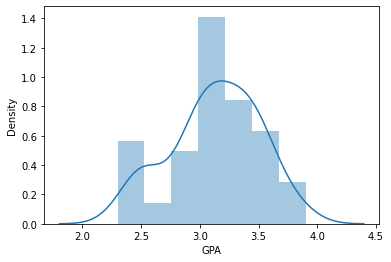

```python
sns.distplot(df['GPA'])
```

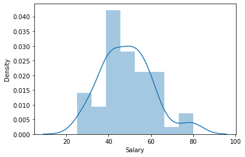

```python
sns.distplot(df['Salary'])
```

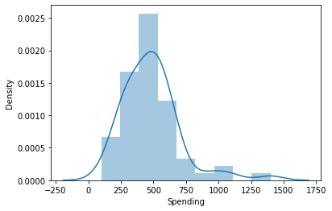

```python
sns.distplot(df['Spending'])
```

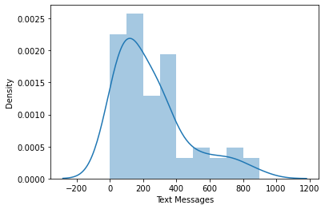

```python
sns.distplot(df['Text Messages'])
```

```python
df[["GPA","Salary","Spending","Text Messages"]].describe().T
```

|  | count | mean | std | min | 25% | 50% | 75% | max |
| --- | --- | --- | --- | --- | --- | --- | --- | --- |
| GPA | 62.0 | 3.129032 | 0.377388 | 2.3 | 2.9 | 3.15 | 3.4 | 3.9 |
| Salary | 62.0 | 48.548387 | 12.080912 | 25.0 | 40.0 | 50.00 | 55.0 | 80.0 |
| Spending | 62.0 | 482.016129 | 221.953805 | 100.0 | 312.5 | 500.00 | 600.0 | 1400.0 |
| Text Messages | 62.0 | 246.209677 | 214.465950 | 0.0 | 100.0 | 200.00 | 300.0 | 900.0 |

Inference : Identifying results using Histogram From the above we can conclude that : - GPA having Normal distribution, salary(little right skewed),spending(right skewed),text messages(right skewed)

# Problem 3:

```python
df5 = pd.read_csv('A & B shingles-1.csv')
df5
```

|  | A | B |
| --- | --- | --- |
| 0 | 0.44 | 0.14 |
| 1 | 0.61 | 0.15 |
| 2 | 0.47 | 0.31 |
| 3 | 0.30 | 0.16 |
| 4 | 0.15 | 0.37 |
| 5 | 0.24 | 0.18 |
| 6 | 0.16 | 0.42 |
| 7 | 0.20 | 0.58 |
| 8 | 0.20 | 0.25 |
| 9 | 0.20 | 0.41 |
| 10 | 0.26 | 0.17 |
| 11 | 0.14 | 0.13 |
| 12 | 0.33 | 0.23 |
| 13 | 0.13 | 0.11 |
| 14 | 0.72 | 0.10 |
| 15 | 0.51 | 0.19 |
| 16 | 0.28 | 0.22 |
| 17 | 0.39 | 0.44 |
| 18 | 0.39 | 0.11 |
| 19 | 0.25 | 0.11 |
| 20 | 0.16 | 0.31 |
| 21 | 0.20 | 0.43 |
| 22 | 0.22 | 0.26 |
| 23 | 0.42 | 0.18 |
| 24 | 0.24 | 0.44 |
| 25 | 0.21 | 0.43 |
| 26 | 0.49 | 0.16 |
| 27 | 0.34 | 0.52 |
| 28 | 0.36 | 0.36 |
| 29 | 0.29 | 0.22 |
| 30 | 0.27 | 0.39 |
| 31 | 0.40 | NaN |
| 32 | 0.29 | NaN |
| 33 | 0.43 | NaN |
| 34 | 0.34 | NaN |
| 35 | 0.37 | NaN |